# RDA project (211004)

Hwang Seong-Yun

2021 11 4

# 농촌진흥청 프로젝트

## 목적 : 단동 비닐하우스 환기율 및 온습도에 대한 예측모형 구축 및 평가

## 사용모형 : Multiple Linear Regression Model v.s Artificial Neural Network Model (ANN)

### Loading data

- 작물있음 데이터에서 외부CO2의 값이 결측치인 경우는 제외하였음.

```r
plantyes <- read.csv("C:/Users/HSY/Desktop/작물있음.csv",sep=",",header=T)
plantyes <- plantyes[is.na(plantyes$외부CO2)==FALSE,]
head(plantyes,10)
```

```
##    외부기온 내부기온 내외부기온차 외부상대습도 내부상대습도 내외부상대습도차
## 1      22.9     31.1          8.3         78.7         55.0             23.7
## 2      22.8     29.7          6.9         77.1         58.7             18.4
## 3      23.3     29.7          6.4         75.5         58.4             17.1
## 4      23.6     29.8          6.2         72.9         57.8             15.1
## 5      24.0     30.0          6.0         71.2         56.4             14.8
## 6      25.1     33.3          8.1         66.6         49.6             17.0
## 7      25.9     35.6          9.7         66.0         43.6             22.4
## 8      25.0     34.0          8.9         68.0         44.9             23.1
## 9      25.9     33.7          7.8         65.6         46.4             19.2
## 10     26.8     35.9          9.1         61.8         44.1             17.7
##    외부CO2 내부CO2 내외부CO2차 외부풍속 외부일사량 환기율 환기창면적 작물유무
## 1    469.5   462.0         7.5    1.398      372.7    5.4       0.15    1.yes
## 2    464.5   459.7         4.8    1.326      309.9    5.0       0.15    1.yes
## 3    457.5   451.3         6.2    0.835      291.9    4.0       0.15    1.yes
```

[output cut: 18 more lines]

```r
plantyes$작물유무 <- as.factor(plantyes$작물유무)
plantno <- read.csv("C:/Users/HSY/Desktop/작물없음.csv",sep=",",header=T)
head(plantno,10)
```

```
##    외부기온 내부기온 내외부기온차 외부상대습도 내부상대습도 내외부상대습도차
## 1      16.8     27.1         10.3         45.1         39.6              5.5
## 2      17.2     28.3         11.1         42.5         37.6              4.9
## 3      17.6     29.1         11.5         42.9         33.2              9.7
## 4      18.0     30.3         12.4         41.2         32.4              8.8
## 5      17.9     30.6         12.7         37.2         28.8              8.4
## 6      18.0     31.3         13.3         37.4         27.1             10.3
## 7      18.0     31.7         13.7         35.8         25.3             10.5
## 8      18.0     32.0         14.0         38.6         24.4             14.2
## 9      18.3     32.7         14.5         37.0         23.5             13.5
## 10     18.3     32.6         14.3         36.1         22.6             13.5
##    외부CO2 내부CO2 내외부CO2차 외부풍속 외부일사량 환기율 환기창면적 작물유무
## 1    543.5   608.0        64.5    1.576      409.4  0.704       0.04     2.no
## 2    543.0   580.0        37.0    1.707      442.7  0.756       0.04     2.no
## 3    522.5   585.5        63.0    1.342      476.5  0.634       0.04     2.no
```

[output cut: 18 more lines]

```r
plantno$작물유무 <- as.factor(plantno$작물유무)
plant <- rbind(plantyes,plantno)
```

### Open library

```r
library(nnet)
library(devtools)
library(neuralnet)
library(NeuralNetTools)
```

- 작물유무에 따라 데이터를 나누어서 사전분석을 실시한 결과 구축된 모형에 많은 차이가 있었다. 이에 따라 작물있음 데이터와 작물없음 데이터를 합친 데이터에 대해 작물유무와 다른 독립변수들간의 교호작용을 포함한 모형을 적합하여 결과를 살펴보았다.

# 1. 환기율 ~ 외부기온, 외부풍속, 외부일사량, 환기창면적, 작물유무

# 작물이 있는 경우

## Multiple Linear Regression Model

- 먼저 변수들 간의 상관관계를 파악하기 위해 상관분석을 실시한다.

```r
ex1 <- plantyes[,c(12,1,10,11,13)]
head(ex1)
```

```
##   환기율 외부기온 외부풍속 외부일사량 환기창면적
## 1    5.4     22.9    1.398      372.7       0.15
## 2    5.0     22.8    1.326      309.9       0.15
## 3    4.0     23.3    0.835      291.9       0.15
## 4    4.2     23.6    0.943      297.5       0.15
## 5    5.2     24.0    1.481      335.4       0.15
## 6    4.9     25.1    1.132      549.7       0.15
```

```r
cor(ex1)
```

```
##                환기율    외부기온   외부풍속  외부일사량  환기창면적
## 환기율     1.00000000  0.04996941 0.76546935  0.10313855  0.67141924
## 외부기온   0.04996941  1.00000000 0.12445561  0.47323743 -0.08617862
## 외부풍속   0.76546935  0.12445561 1.00000000  0.01247939  0.10718424
## 외부일사량 0.10313855  0.47323743 0.01247939  1.00000000 -0.01979362
## 환기창면적 0.67141924 -0.08617862 0.10718424 -0.01979362  1.00000000
```

- 분석결과, pearson 표본상관계수에 따르면 환기창면적과 외부기온, 환기창면적과 외부일사량은 서로 약한 음의 상관관계를 보이고 있으며, 나머지는 모두 양의 상관관계를 보이고 있다. 이를 그림으로 그리면 다음과 같다.

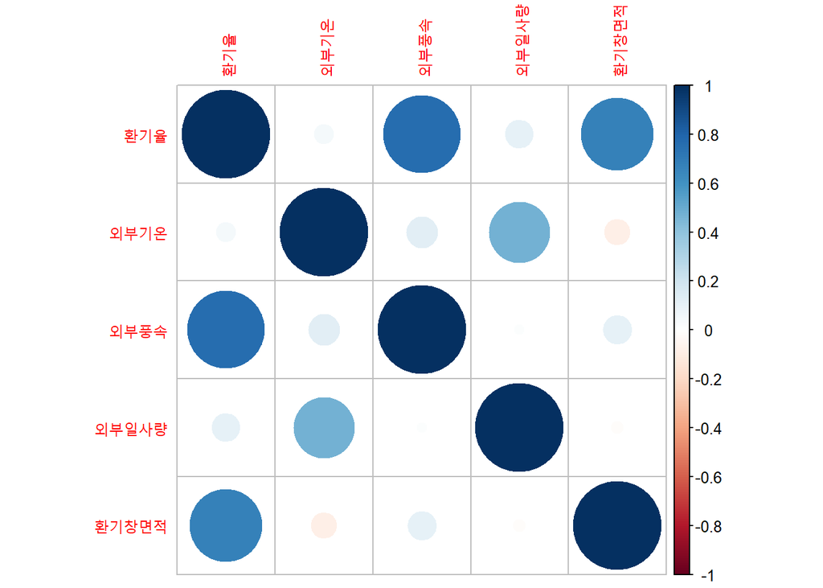

```r
library(corrplot)
corrplot(cor(ex1))
```

- 그리고 각 변수에 대한 기초통계량은 다음과 같이 계산된다. 이 결과에 의하면 5가지 변수들 중 외부일사량이 가장 변동이 크다고 할 수 있다.

```r
library(psych)
describe(ex1)
```

```
##            vars    n   mean     sd median trimmed    mad   min    max  range
## 환기율        1 1055   5.15   2.58   4.60    4.77   2.08  1.40  20.90  19.50
## 외부기온      2 1055  26.91   2.99  26.90   26.94   3.26 17.30  33.90  16.60
## 외부풍속      3 1055   1.50   0.92   1.30    1.41   0.83  0.00   6.22   6.21
## 외부일사량    4 1055 459.27 225.19 459.20  460.76 275.02 10.04 950.00 939.96
## 환기창면적    5 1055   0.13   0.03   0.12    0.13   0.04  0.09   0.18   0.09
##             skew kurtosis   se
## 환기율      1.62     3.44 0.08
## 외부기온   -0.12    -0.42 0.09
## 외부풍속    0.97     0.80 0.03
## 외부일사량 -0.02    -1.02 6.93
## 환기창면적  0.12    -1.38 0.00
```

- 모형을 적합하기 전 주어진 데이터를 임의로 train:test=7:3으로 나누어서 train data를 가지고 적절한 모형을 적합하고 이 모형을 test data를 이용하여 평가할 것이다. 이는 ANN을 적용하는 경우에도 마찬가지이다.

```r
set.seed(5790)
train.index <- sample(1:nrow(ex1), round(nrow(ex1)*7/10), replace=F)
ex1_train <- ex1[train.index,]
ex1_test <- ex1[-train.index,]
```

- train data에 대해 다중선형회귀모형을 다음과 같이 적합할 수 있다.

```r
m0 <- lm(환기율~외부기온+외부풍속+외부일사량+환기창면적,
            data=ex1_train)
summary(m0)
```

```
##
## Call:
## lm(formula = 환기율 ~ 외부기온 + 외부풍속 + 외부일사량 + 환기창면적,
##     data = ex1_train)
##
## Residuals:
##      Min       1Q   Median       3Q      Max
## -1.49852 -0.34991 -0.05476  0.27258  2.48444
##
## Coefficients:
##               Estimate Std. Error t value Pr(>|t|)
## (Intercept) -3.5600497  0.2284734  -15.58  < 2e-16 ***
## 외부기온    -0.0393246  0.0083672   -4.70 3.11e-06 ***
## 외부풍속     1.9895977  0.0227275   87.54  < 2e-16 ***
## 외부일사량   0.0015049  0.0001078   13.96  < 2e-16 ***
## 환기창면적  45.2232703  0.6190881   73.05  < 2e-16 ***
## ---
## Signif. codes:  0 '***' 0.001 '**' 0.01 '*' 0.05 '.' 0.1 ' ' 1
##
## Residual standard error: 0.5648 on 733 degrees of freedom
## Multiple R-squared:  0.9536, Adjusted R-squared:  0.9533
## F-statistic:  3765 on 4 and 733 DF,  p-value: < 2.2e-16
```

- 모형적합 결과 외부기온, 외부풍속, 외부일사량, 환기창면적 모두 환기율에 유의미한 영향을 미치고 있다고 보여진다. 그리고 조절된 결정계수의 값이 $R^2_{adj}=0.9533$이므로 이 모형이 데이터의 변동을 약 $95%$ 정도 설명하고 있으므로 설명력도 크다는 것을 알 수 있다. 따라서 더이상의 변수선택과정은 필요없을 것으로 판단되며 이에 따라 최종적인 모형식을 다음과 같이 표현할 수 있겠다.
- ${\hat{y}} = -3.5600 - 0.0393x_{1} + 1.9896x_{2} + 0.0015x_{3} + 45.2233x_{4}$
- $y$ : 환기율, $x _{1}$ : 외부기온, $x _{2}$ : 외부풍속, $x_{3}$ : 외부일사량, $x_{4}$ : 환기창면적
- 이 모형을 이용하여 test data에 대한 환기율의 예측값을 구하고 이를 바탕으로 예측력의 정확성을 판단하는 기준인 RMSE를 계산하도록 한다. 이는 다음과 같이 계산한다.
- $RMSE = \frac {1} {n} \sqrt {\sum _{i=1} ^{n} (y _{i} - {\hat{y _{i}}} ) ^{2}}$

```r
y_hat <- predict(m0,ex1_test)
RMSE <- mean(sum((ex1_test$환기율-y_hat)^2))
RMSE
```

```
## [1] 113.8861
```

# 작물이 없는 경우

- 작물이 있는 경우와 동일한 과정으로 분석을 실시한다.

## Multiple Linear Regression Model

- 먼저 변수들 간의 상관관계를 파악하기 위해 상관분석을 실시한다.

```r
ex2 <- plantno[,c(12,1,10,11,13)]
head(ex2)
```

```
##   환기율 외부기온 외부풍속 외부일사량 환기창면적
## 1  0.704     16.8    1.576      409.4       0.04
## 2  0.756     17.2    1.707      442.7       0.04
## 3  0.634     17.6    1.342      476.5       0.04
## 4  0.798     18.0    1.802      505.7       0.04
## 5  1.084     17.9    2.583      536.0       0.04
## 6  1.493     18.0    3.660      564.9       0.04
```

```r
cor(ex2)
```

```
##               환기율      외부기온     외부풍속    외부일사량    환기창면적
## 환기율     1.0000000  1.668245e-01 5.063954e-01  6.080400e-02  8.309530e-01
## 외부기온   0.1668245  1.000000e+00 3.063871e-01  3.274643e-01 -9.044468e-20
## 외부풍속   0.5063954  3.063871e-01 1.000000e+00  4.772916e-02  3.715441e-20
## 외부일사량 0.0608040  3.274643e-01 4.772916e-02  1.000000e+00 -5.089237e-20
## 환기창면적 0.8309530 -9.044468e-20 3.715441e-20 -5.089237e-20  1.000000e+00
```

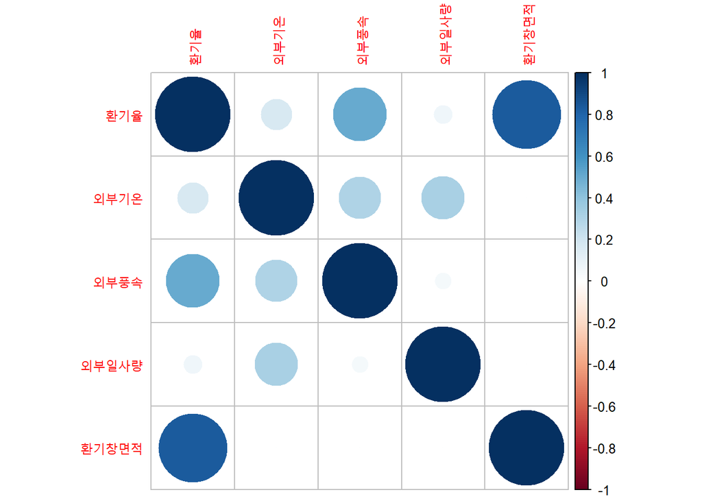

```r
corrplot(cor(ex2))
```

- 그리고 각 변수에 대한 기초통계량은 다음과 같이 계산된다. 이 결과에 의하면 5가지 변수들 중 외부일사량이 가장 변동이 크다고 할 수 있다.

```r
describe(ex2)
```

```
##            vars   n   mean     sd median trimmed    mad    min    max  range
## 환기율        1 735   2.81   1.64   2.64    2.68   1.86   0.32   7.09   6.78
## 외부기온      2 735  23.39   2.30  24.00   23.66   1.93  16.80  27.00  10.20
## 외부풍속      3 735   2.71   1.08   2.87    2.73   1.29   0.21   4.74   4.54
## 외부일사량    4 735 568.60 171.31 601.10  584.32 191.40 143.00 795.20 652.20
## 환기창면적    5 735   0.09   0.04   0.09    0.09   0.07   0.04   0.15   0.11
##             skew kurtosis   se
## 환기율      0.55    -0.67 0.06
## 외부기온   -0.98     0.30 0.08
## 외부풍속   -0.26    -0.99 0.04
## 외부일사량 -0.63    -0.61 6.32
## 환기창면적  0.11    -1.50 0.00
```

- 모형을 적합하기 전 주어진 데이터를 임의로 train:test=7:3으로 나누어서 train data를 가지고 적절한 모형을 적합하고 이 모형을 test data를 이용하여 평가할 것이다. 이는 ANN을 적용하는 경우에도 마찬가지이다.

```r
set.seed(5790)
train.index <- sample(1:nrow(ex2), round(nrow(ex2)*7/10), replace=F)
ex2_train <- ex2[train.index,]
ex2_test <- ex2[-train.index,]
```

- train data에 대해 다중선형회귀모형을 다음과 같이 적합할 수 있다.

```r
m0 <- lm(환기율~외부기온+외부풍속+외부일사량+환기창면적,data=ex2_train)
summary(m0)
```

```
##
## Call:
## lm(formula = 환기율 ~ 외부기온 + 외부풍속 + 외부일사량 + 환기창면적,
##     data = ex2_train)
##
## Residuals:
##      Min       1Q   Median       3Q      Max
## -0.99801 -0.24674  0.04827  0.17975  1.08904
##
## Coefficients:
##               Estimate Std. Error t value Pr(>|t|)
## (Intercept) -2.2933242  0.1742529 -13.161  < 2e-16 ***
## 외부기온     0.0007205  0.0082379   0.087  0.93034
## 외부풍속     0.7554714  0.0163355  46.247  < 2e-16 ***
## 외부일사량   0.0003220  0.0001067   3.019  0.00267 **
## 환기창면적  30.6291872  0.3757391  81.517  < 2e-16 ***
## ---
## Signif. codes:  0 '***' 0.001 '**' 0.01 '*' 0.05 '.' 0.1 ' ' 1
##
## Residual standard error: 0.3806 on 509 degrees of freedom
## Multiple R-squared:  0.9469, Adjusted R-squared:  0.9464
## F-statistic:  2267 on 4 and 509 DF,  p-value: < 2.2e-16
```

- 모형적합 결과 외부풍속, 외부일사량, 환기창면적 모두 환기율에 유의미한 영향을 미치고 있지만, 외부기온은 유의미한 영향력이 없음을 알 수 있다. 이에 따라 stepwise selection을 통해 적절한 변수를 선택하는 과정이 필요하다고 판단된다.

```r
m1 <- step(m0)
```

```
## Start:  AIC=-987.96
## 환기율 ~ 외부기온 + 외부풍속 + 외부일사량 + 환기창면적
##
##              Df Sum of Sq     RSS     AIC
## - 외부기온    1      0.00   73.75 -989.95
## <none>                      73.75 -987.96
## - 외부일사량  1      1.32   75.07 -980.84
## - 외부풍속    1    309.89  383.64 -142.35
## - 환기창면적  1    962.80 1036.55  368.53
##
## Step:  AIC=-989.95
## 환기율 ~ 외부풍속 + 외부일사량 + 환기창면적
##
##              Df Sum of Sq     RSS     AIC
## <none>                      73.75 -989.95
## - 외부일사량  1      1.53   75.28 -981.37
## - 외부풍속    1    351.60  425.35  -91.31
## - 환기창면적  1    963.20 1036.95  366.73
```

```r
summary(m1)
```

```
##
## Call:
## lm(formula = 환기율 ~ 외부풍속 + 외부일사량 + 환기창면적, data = ex2_train)
##
## Residuals:
##      Min       1Q   Median       3Q      Max
## -1.00012 -0.24677  0.04883  0.17982  1.08815
##
## Coefficients:
##               Estimate Std. Error t value Pr(>|t|)
## (Intercept) -2.280e+00  7.911e-02 -28.816   <2e-16 ***
## 외부풍속     7.560e-01  1.533e-02  49.309   <2e-16 ***
## 외부일사량   3.253e-04  9.986e-05   3.257   0.0012 **
## 환기창면적   3.063e+01  3.753e-01  81.613   <2e-16 ***
## ---
## Signif. codes:  0 '***' 0.001 '**' 0.01 '*' 0.05 '.' 0.1 ' ' 1
##
## Residual standard error: 0.3803 on 510 degrees of freedom
## Multiple R-squared:  0.9469, Adjusted R-squared:  0.9465
## F-statistic:  3028 on 3 and 510 DF,  p-value: < 2.2e-16
```

- stepwise selection에 따른 최종적인 모형식은 다음과 같다.
- ${\hat{y}} = -2.2800 + 0.7560x_{2} + 0.0003x_{3} + 30.630x_{4}$
- $y$ : 환기율, $x _{2}$ : 외부풍속, $x_{3}$ : 외부일사량, $x_{4}$ : 환기창면적
- 즉, 환기율은 외부풍속, 외부일사량, 환기창면적에 대해 모두 정비례하는 경향을 보이고 있다.
- 이 모형을 이용하여 test data에 대한 환기율의 예측값을 구하고 이를 바탕으로 예측력의 정확성을 판단하는 기준인 RMSE를 계산하도록 한다. 이는 다음과 같이 계산한다.
- $RMSE = \frac {1} {n} \sqrt {\sum _{i=1} ^{n} (y _{i} - {\hat{y _{i}}} ) ^{2}}$

```r
y_hat <- predict(m1,ex2_test)
RMSE <- mean(sum((ex2_test$환기율-y_hat)^2))
RMSE
```

```
## [1] 28.49331
```